# Predicting Property Maintenance Fines for City of Detroit

This project is based on an assigment from Coursera course [Applied Machine Learning in Python- University of Michigan](https://www.coursera.org/learn/python-machine-learning/home/welcome). The goal of the project is to predict whether a property maintenance fine will be paid by a violator. The fines are issued by the city to individuals who allow their properties to remain in a deteriorated condition. Data has been provided to the course through the [Detroit Open Data Portal](https://data.detroitmi.gov/).

Two data files were provided for training and validating the models: train.csv and test.csv. Each row in these two files corresponds to a single blight ticket, and includes information about when, why, and to whom each ticket was issued. The target variable is compliance, which is True if the ticket was paid early, on time, or within one month of the hearing data, False if the ticket was paid after the hearing date or not at all, and Null if the violator was found not responsible. Compliance, as well as a handful of other variables that will not be available at test-time, are only included in train.csv.

Note: All tickets where the violators were found not responsible are not considered during evaluation. They are included in the training set as an additional source of data for visualization, and to enable unsupervised and semi-supervised approaches. However, they are not included in the test set.

```python
import pandas as pd
import numpy as np
import string
from scipy.stats import randint
import matplotlib.pyplot as plt
import seaborn as sns
from sklearn.preprocessing import LabelEncoder, OneHotEncoder, Imputer, LabelBinarizer, Normalizer
from sklearn.model_selection import train_test_split, cross_val_score, RandomizedSearchCV
from sklearn.ensemble import RandomForestClassifier
import pickle
from sklearn.externals import joblib
%matplotlib inline
```

### Define helper functions for pre-processing and data analysis

```python
# column comparison
def col_comparison(df1, df2):
    '''
    compare two dataframes to see which columns are in both set,
    in set1 only, and in set2 only
    arguments: df1, df2
    returns: samecols, df1only, df2only
    '''
    df1Cols = set(list(df1.columns.values))
    df2Cols = set(list(df2.columns.values))
    samecols = list(df1Cols.intersection(df2Cols))
    df1only = list(df1Cols & set(df1Cols ^ df2Cols))
    df2only = list(df2Cols & set(df1Cols ^ df2Cols))
    df1name =[x for x in globals() if globals()[x] is df1][0]
    df2name =[x for x in globals() if globals()[x] is df2][0]
    print('------ columns in both sets -----')
    print(samecols)
    print('')
    print('------ columns in %s only ----- ' % (df1name))
    print(df1only)
    print('')
    print('------ columns in %s only ----- ' % (df2name))
    print(df2only)

    return samecols, df1only, df2only

# basic data info
def show_info(df):
    '''print out information about dataframe
    Argument: dataframe name
    Return: none
    '''
    objectsCols = df.loc[:, df.dtypes == object].columns
    #print(df.info())

    print("------Description of Dataset -------" )
    print(df.describe())

    print("------Description of Dtypes --------" )
    print(df.dtypes)

    print("------Grouping by Dtypes --------" )
    print(df.columns.to_series().groupby(df.dtypes).groups)               # group by data types

    print("------count of unique values -------" )
    uniqueVals = df.loc[:,objectsCols].apply(lambda x: len(x.unique()))   # print count of unique values for object data types
    print(uniqueVals)

    print("-----print count for each categorie----")
    categories = uniqueVals[uniqueVals <= 20].index
    for x in categories:
        print("--count in category " + x + "--")
        print(df[x].value_counts())

    print("------count of np.nan -------" )
    print(df.isnull().sum())

    print("------zero variance numeric columns -------" )
    print(df.std()[df.std() == 0].index.values)

    return

# define columns to add drop so train and test set matches
def make_cols_match(train, test, y_name):
    '''define columns to add drop so two datasets matches
    Arguments: train, test, y_name (dataframe 1, dataframe 2, output variable y in quotes)
    Returns: train, test
    '''
    print("---columns comparsion prior to change---")
    samecols, df1only, df2only = col_comparison(train, test)
    train_y = train[y_name]

    # remove columns only in train
    train = remove_columns(train, df1only)

    # remove columns only in test
    test = remove_columns(test, df2only)

    # append y_name to test and train
    train[y_name] = train_y
    test[y_name] = '0'


    return train, test

# show near-zero variance numeric columns
def nearZeroCols(df, threshold):
    '''show near-zero variance numeric columns <= to a threshold
    Arguments: df, threshold
    Returns: array of column names<= threshold
    '''
    return df.std()[df.std() <= threshold].index.values

# change data type
def cast_dtype(df, cols, dtype):
    '''
    change datatype of dataframe given column names
    Arguments: df: dataframe, cols: list of column names [], dtype: data type to cast to i.e.: 'int64', 'float64', 'str'
    Returns: dataframe
    '''
    df[cols] = df[cols].astype(dtype)

    return df


def cast_datetime(df, cols):
    '''
    change datatype of dataframe to datetime given column names
    Arguments: df: dataframe, cols: column names in [' ', ' ']
    Returns: dataframe
    '''
    df.loc[:, cols] = df.loc[:, cols].apply(pd.to_datetime, errors='coerce')

    return df


# text processing
def process_text(text):
    '''
    perform a variety of transformations to text
    Argument: text
    Returns: text
    '''
    text = text.replace(r'.0', '')                  # remove .0 from the end of strings
    text = text.translate(str.maketrans('', '', string.punctuation)) # remove punctuation
    text = text.lstrip('0')                         # strip leading 0
    text = ' '.join(text.split())                   # strip multiple whitespaces into 1
    text = text.strip()                             # strip whitespace
    text = text.lower()                             # convert to lower case

    return text

def textProcessing(df, cols):
    '''
    apply transformation of text to specified columns in a dataframe using function 'process_text'
    Arguments: dataframe, list of column names to transform
    Returns: dataframe'''

    if cols is None:
        stringCols = df.loc[:, df.dtypes == object].columns
        dateTimeCols = df.select_dtypes(include=['datetime64']).columns
        cols = list(set(stringCols)-set(dateTimeCols))

    df.loc[:, cols] = df.loc[:, cols].applymap(lambda x: process_text(x))

    return df

# remove selected columns
def remove_columns(df, cols):
    ''' remove list of columns given a dataframe.  Error will not rise if column names are not in the dataframe
    Arguments: dataframe, list of column names
    Returns: dataframe'''

    cols = list(set(cols).intersection(df.columns))  # to avoid error, delete the named columns in dataframe's columns
    df = df.drop(cols, axis = 1)
    return df

# keep columns that are in both sets only
def keep_columns_in_both_sets(df1, df2):
    ''' given two dataframes, only keep columns that are in both dataframes
    Arguments: dataframe1, dataframe2
    Returns: dataframe1, dataframe2 '''

    cols = list(set(list(df1.columns.values)).intersection(list(df2.columns.values)))
    df1 = df1.loc[:,cols]
    df2 = df2.loc[:,cols]
    return df1, df2

# check for common form to signify missing observations, i.e. "0" or "nan" or "blank"
def missing_obs_count_by_column(df, cols, stringlist):
    ''' count the number of observations per columns (only string columns) in a dataframe
    given a list of values to match to

    Arguments: dataframe, columns to search, strings to match
    Returns: print out report'''

    if stringlist is None:
        stringlist = ['0', 'nan', '', 'missing', 'none', 'na']

    if cols is None:
        stringCols = df.loc[:, df.dtypes == object].columns
        dateTimeCols = df.select_dtypes(include=['datetime64']).columns
        cols = list(set(stringCols)-set(dateTimeCols))

    for string in stringlist:
        print('-----' + string + '------')
        print(np.sum(df.loc[:, cols].apply(lambda x: x == string)))
    return


# replace strings
def replaceStrings(df, cols, pattern, replaceTo):
    ''' given a datframe and columns, replace the values of the observations given a pattern to match, and value to replace to
    Arguments: dataframe, columns, pattern to match, value to replace to
    Retruns: dataframe
    '''
    for col in cols:
        #df.loc[col] = df.loc[col].replace(pattern, replaceTo)
        df[col] = df[col].replace(pattern, replaceTo)
    return df


# drop near-zero variance numeric columns
def drop_features_based_on_std_threshold(df, threshold):
    '''given a dataframe, and threshold, drop columns with standard deviations
    that are under or equal to the threshold
    Arguments: dataframe, threshold
    Returns: dataframe '''

    uint8Cols = df.loc[:, df.dtypes == 'uint8'].columns
    float64Cols = df.loc[:, df.dtypes == 'float64'].columns
    cols = uint8Cols.append(float64Cols)

    stdCalc = df.loc[:,cols].apply(lambda x: np.std(x))
    sparseFeatures = stdCalc[stdCalc <= threshold].index

    df = df.drop(sparseFeatures, axis = 1)
    return df

    # This implementation is very slow
    #df = df.drop(df.std()[df.std() <= threshold].index.values, axis=1)
    #return df


# show uint8 columns with less than a threshold
def show_features_fewer_than_count(df, threshold):
    '''
    show uint8 columns with less than a threshold
    given a dataframe, filter columns that are uin8 (dummy variables)
    return series showing features with counts fewer than the threshold
    Arguments: dataframe, threshold for filtering count
    Return: a filtered named series with counts of none-zeros
    '''

    uint8Cols = df.loc[:, df.dtypes == 'uint8'].columns
    numCount = df.loc[:,uint8Cols].apply(lambda x: np.sum(x))
    sparseFeatures = numCount[numCount <= threshold]

    return sparseFeatures

# remove uint8 columns with less than a threshold
def remove_features_fewer_than_count(df, threshold):
    '''
    remove uint8 columns with less than a threshold
    given a dataframe, filter columns that are uin8 (dummy variables)
    delete sparse features from dataframe
    Arguments: dataframe, threshold for filtering count
    Return: dataframe
    '''
    uint8Cols = df.loc[:, df.dtypes == 'uint8'].columns
    numCount = df.loc[:,uint8Cols].apply(lambda x: np.sum(x))
    sparseFeatures = numCount[numCount <= threshold].index

    df = df.drop(sparseFeatures, axis = 1)
    return df
```

### Review Data

#### Import files

```python
train_orig = pd.read_csv('train.csv', encoding = 'ISO-8859-1', dtype = object)
test = pd.read_csv('test.csv', dtype = object)
coord = pd.read_csv('latlons.csv')
```

#### Review summary of data

```python
train_orig.head(3)
```

|  | ticket_id | agency_name | inspector_name | violator_name | violation_street_number | violation_street_name | violation_zip_code | mailing_address_str_number | mailing_address_str_name | city | ... | clean_up_cost | judgment_amount | payment_amount | balance_due | payment_date | payment_status | collection_status | grafitti_status | compliance_detail | compliance |
| --- | --- | --- | --- | --- | --- | --- | --- | --- | --- | --- | --- | --- | --- | --- | --- | --- | --- | --- | --- | --- | --- |
| 0 | 22056 | Buildings, Safety Engineering & Env Department | Sims, Martinzie | INVESTMENT INC., MIDWEST MORTGAGE | 2900.0 | TYLER | NaN | 3 | S. WICKER | CHICAGO | ... | 0.0 | 305.0 | 0.0 | 305.0 | NaN | NO PAYMENT APPLIED | NaN | NaN | non-compliant by no payment | 0.0 |
| 1 | 27586 | Buildings, Safety Engineering & Env Department | Williams, Darrin | Michigan, Covenant House | 4311.0 | CENTRAL | NaN | 2959 | Martin Luther King | Detroit | ... | 0.0 | 855.0 | 780.0 | 75.0 | 2005-06-02 00:00:00 | PAID IN FULL | NaN | NaN | compliant by late payment within 1 month | 1.0 |
| 2 | 22062 | Buildings, Safety Engineering & Env Department | Sims, Martinzie | SANDERS, DERRON | 1449.0 | LONGFELLOW | NaN | 23658 | P.O. BOX | DETROIT | ... | 0.0 | 0.0 | 0.0 | 0.0 | NaN | NO PAYMENT APPLIED | NaN | NaN | not responsible by disposition | NaN |

3 rows × 34 columns

```python
test.head(3)
```

|  | ticket_id | agency_name | inspector_name | violator_name | violation_street_number | violation_street_name | violation_zip_code | mailing_address_str_number | mailing_address_str_name | city | ... | violation_description | disposition | fine_amount | admin_fee | state_fee | late_fee | discount_amount | clean_up_cost | judgment_amount | grafitti_status |
| --- | --- | --- | --- | --- | --- | --- | --- | --- | --- | --- | --- | --- | --- | --- | --- | --- | --- | --- | --- | --- | --- |
| 0 | 284932 | Department of Public Works | Granberry, Aisha B | FLUELLEN, JOHN A | 10041.0 | ROSEBERRY | NaN | 141 | ROSEBERRY | DETROIT | ... | Failure to secure City or Private solid waste ... | Responsible by Default | 200.0 | 20.0 | 10.0 | 20.0 | 0.0 | 0.0 | 250.0 | NaN |
| 1 | 285362 | Department of Public Works | Lusk, Gertrina | WHIGHAM, THELMA | 18520.0 | EVERGREEN | NaN | 19136 | GLASTONBURY | DETROIT | ... | Allowing bulk solid waste to lie or accumulate... | Responsible by Default | 1000.0 | 20.0 | 10.0 | 100.0 | 0.0 | 0.0 | 1130.0 | NaN |
| 2 | 285361 | Department of Public Works | Lusk, Gertrina | WHIGHAM, THELMA | 18520.0 | EVERGREEN | NaN | 19136 | GLASTONBURY | DETROIT | ... | Improper placement of Courville container betw... | Responsible by Default | 100.0 | 20.0 | 10.0 | 10.0 | 0.0 | 0.0 | 140.0 | NaN |

3 rows × 27 columns

Compare columns between the two datasets

```python
samecols, df1only, df2only = col_comparison(train_orig, test)
```

```
------ columns in both sets -----
['grafitti_status', 'ticket_issued_date', 'inspector_name', 'non_us_str_code', 'fine_amount', 'late_fee', 'violation_code', 'violation_street_name', 'violation_street_number', 'admin_fee', 'violation_description', 'mailing_address_str_number', 'judgment_amount', 'hearing_date', 'state', 'state_fee',…

------ columns in train_orig only -----
['payment_date', 'compliance_detail', 'balance_due', 'compliance', 'payment_amount', 'payment_status', 'collection_status']

------ columns in test only -----
[]
```

Show description of training set

```python
show_info(train_orig)
```

```
------Description of Dataset -------
       ticket_id                                     agency_name  \
count     250306                                          250306
unique    250306                                               5
top       237420  Buildings, Safety Engineering & Env Department
freq           1                                          157784

       inspector_name      violator_name violation_street_number  \
count          250306             250272                  250306
unique            173             119992                   19175
top      Morris, John  INVESTMENT, ACORN                  1509.0
freq            17926                809                     240

       violation_street_name  violation_zip_code mailing_address_str_number  \
count                 250306                 0.0                     246704
unique                  1791                 0.0                      15826
top               SEVEN MILE                 NaN                        213
freq                    3482                 NaN                       1934

       mailing_address_str_name     city    ...     clean_up_cost  \
count                    250302   250306    ...            250306
unique                    37896     5184    ...                 1
top                      PO BOX  DETROIT    ...               0.0
freq                       8668   136936    ...            250306

       judgment_amount payment_amount balance_due         payment_date  \
count           250306         250306      250306                41113
unique              57            533         607                 2307
top                0.0            0.0         0.0  2014-08-04 00:00:00
freq             90621         209193      111508                  177

            payment_status collection_status  grafitti_status  \
count               250306             36897                1
unique                   3                 1                1
top     NO PAYMENT APPLIED     IN COLLECTION  GRAFFITI TICKET
freq                209193             36897                1

                  compliance_detail compliance
count                        250306     159880
unique                           10          2
```

[output cut: 196 more lines]

```
late_fee                           0
discount_amount                    0
clean_up_cost                      0
judgment_amount                    0
payment_amount                     0
balance_due                        0
payment_date                  209193
payment_status                     0
collection_status             213409
grafitti_status               250305
compliance_detail                  0
compliance                     90426
dtype: int64
------zero variance numeric columns -------
[]
```

Show description of testing set

```python
show_info(test)
```

```
------Description of Dataset -------
       ticket_id                 agency_name inspector_name  \
count      61001                       61001          61001
unique     61001                           3            116
top       312370  Department of Public Works    Zizi, Josue
freq           1                       40731           6293

             violator_name violation_street_number violation_street_name  \
count                60973                   61001                 61001
unique               38515                   13999                  1477
top     HOMES LDHA LP, MLK                 16700.0             MCNICHOLS
freq                    91                      55                  1125

       violation_zip_code mailing_address_str_number mailing_address_str_name  \
count               24024                      59987                    60998
unique                 58                       9703                    16851
top                 48228                          4              GRAND RIVER
freq                 2648                        630                      479

           city       ...         \
count     61000       ...
unique     3266       ...
top     DETROIT       ...
freq      26358       ...

                                    violation_description  \
count                                               61001
unique                                                163
top     Excessive weeds or plant growth one- or two-fa...
freq                                                16259

                   disposition  fine_amount admin_fee state_fee late_fee  \
count                    61001        61001     61001     61001    61001
unique                       8           53         1         1       44
top     Responsible by Default         50.0      20.0      10.0      5.0
freq                     51602        17322     61001     61001    15023

       discount_amount clean_up_cost judgment_amount  grafitti_status
count            61001         61001           61001             2221
unique              14           298             503                1
```

[output cut: 134 more lines]

```
hearing_date                   2197
violation_code                    0
violation_description             0
disposition                       0
fine_amount                       0
admin_fee                         0
state_fee                         0
late_fee                          0
discount_amount                   0
clean_up_cost                     0
judgment_amount                   0
grafitti_status               58780
dtype: int64
------zero variance numeric columns -------
[]
```

### Preliminary Pre-processing

#### Make columns in the training and testing dataset match.

```python
train, test = make_cols_match(train_orig, test, 'compliance')
```

```
---columns comparsion prior to change---
------ columns in both sets -----
['grafitti_status', 'ticket_issued_date', 'inspector_name', 'non_us_str_code', 'fine_amount', 'late_fee', 'violation_code', 'violation_street_name', 'violation_street_number', 'admin_fee', 'violation_description', 'mailing_address_str_number', 'judgment_amount', 'hearing_date', 'state', 'state_fee',…

------ columns in train_orig only -----
['payment_date', 'compliance_detail', 'balance_due', 'compliance', 'payment_amount', 'payment_status', 'collection_status']

------ columns in test only -----
[]
```

Verify that columns now match between the two sets

```python
train.columns == test.columns
```

```
array([ True,  True,  True,  True,  True,  True,  True,  True,  True,
        True,  True,  True,  True,  True,  True,  True,  True,  True,
        True,  True,  True,  True,  True,  True,  True,  True,  True,  True], dtype=bool)
```

#### Remove rows from training sets where the violators were found not responsible for the ticket issued.

```python
train = train.dropna(subset=['compliance'])
```

#### Define function to apply transformations

```python
def transformations(df):

    # cast to string for categorical variables
    df = cast_dtype(df, ['fine_amount', 'admin_fee', 'state_fee', 'late_fee', 'discount_amount',
                         'clean_up_cost', 'judgment_amount'], 'float64')

    df = cast_dtype(df, ['ticket_id', 'agency_name', 'inspector_name', 'violator_name',
       'violation_street_number', 'violation_street_name',
       'violation_zip_code', 'mailing_address_str_number',
       'mailing_address_str_name', 'city', 'state', 'zip_code',
       'non_us_str_code', 'country', 'violation_code', 'violation_description',
       'disposition', 'grafitti_status', 'compliance'], 'str')


    # cast to datetime for date time variables
    df = cast_datetime(df, ['ticket_issued_date', 'hearing_date'])

    # select string columns for text processing
    df = textProcessing(df, cols = None)

    # select columns to remove
    cols = ['violation_zip_code', 'non_us_str_code', 'country', 'grafitti_status', 'clean_up_cost', 'violation_description',
             'mailing_address_str_number', 'mailing_address_str_name']
    df = remove_columns(df, cols)

    # check for common form of missing observations
    #print('---missing observations in these columns prior to replacing strings---')
    #print(missing_obs_count_by_column(df, cols = None, stringlist = None))

    # replace strings that are missing
    df = replaceStrings(df, ['zip_code', 'state', 'violator_name'], 'nan', '')
    df['compliance'] = df['compliance'].replace('', '0')

    # drop zero variance numeric columns
    df = drop_features_based_on_std_threshold(df, 0)

    return df
```

#### Apply Transformations

1. cast to float64 for numeric variables
2. cast to string for categorical variables
3. cast to datetime for date time variables
4. select string columns for text processing
5. select columns to remove
6. replace strings that are missing
7. drop numeric columns with zero variance

```python
train = transformations(train)
test = transformations(test)
```

Check the data summary again after transformations

```python
show_info(train)
```

```
------Description of Dataset -------
         fine_amount       late_fee  discount_amount  judgment_amount
count  159880.000000  159880.000000    159880.000000    159880.000000
mean      357.035295      33.651512         0.195959       420.650218
std       675.655580      67.692916         4.290344       742.555062
min         0.000000       0.000000         0.000000         0.000000
25%       200.000000      10.000000         0.000000       250.000000
50%       250.000000      25.000000         0.000000       305.000000
75%       250.000000      25.000000         0.000000       305.000000
max     10000.000000    1000.000000       350.000000     11030.000000
------Description of Dtypes --------
ticket_id                          object
agency_name                        object
inspector_name                     object
violator_name                      object
violation_street_number            object
violation_street_name              object
city                               object
state                              object
zip_code                           object
ticket_issued_date         datetime64[ns]
hearing_date               datetime64[ns]
violation_code                     object
disposition                        object
fine_amount                       float64
late_fee                          float64
discount_amount                   float64
judgment_amount                   float64
compliance                         object
dtype: object
------Grouping by Dtypes --------
{dtype('<M8[ns]'): Index(['ticket_issued_date', 'hearing_date'], dtype='object'), dtype('float64'): Index(['fine_amount', 'late_fee', 'discount_amount', 'judgment_amount'], dtype='object'), dtype('O'): Index(['ticket_id', 'agency_name', 'inspector_name', 'violator_name',
       'violation_street_number', 'violation_street_name', 'city', 'state',
       'zip_code', 'violation_code', 'disposition', 'compliance'],
      dtype='object')}
------count of unique values -------
ticket_id                  159880
agency_name                     5
inspector_name                158
violator_name               75209
```

[output cut: 34 more lines]

```
city                         0
state                        0
zip_code                     0
ticket_issued_date           0
hearing_date               227
violation_code               0
disposition                  0
fine_amount                  0
late_fee                     0
discount_amount              0
judgment_amount              0
compliance                   0
dtype: int64
------zero variance numeric columns -------
[]
```

### Feature Engineering

#### Boolean: if state of violator is in MI

```python
train['mi'] = [1 if  x == 'mi' else 0 for x in train['state']]
test['mi'] = [1 if  x == 'mi' else 0 for x in test['state']]
```

#### Boolean: if violator is in Detroit or not

```python
train['detroit'] = train['city'] .str.startswith('det')
test['detroit'] = test['city'] .str.startswith('det')
```

#### Boolean: if violator has only 1 violation

```python
def oneRecord(feature, df1, df2):
    '''given a column, find observations counts with only only one observation.
    The function combines both df1 and df2 before proceed with calculation
    Arguments: column (feature), dataframe1, dataframe2
    Returns: dataframe with two columns: feature & '''

    temp = pd.concat([df1[feature].reset_index(),
                      df2[feature].reset_index()])
    temp = temp.groupby(feature, as_index = False).count()
    return temp[temp['index'] == 1]

singleViolation = oneRecord('violator_name', train, test)
train = train.merge(singleViolation, how = 'left', left_on= 'violator_name', right_on = 'violator_name')
test = test.merge(singleViolation, how = 'left', left_on= 'violator_name', right_on = 'violator_name')
train = train.rename(columns={'index':'singleViolation'})
test = test.rename(columns={'index':'singleViolation'})
train['singleViolation'].fillna(0, inplace = True)
test['singleViolation'].fillna(0, inplace = True)
```

#### Group features by number count and % of occurence for high-cardinality categorical attributes

zip_code, violator_name, inspector_name

```python
def percentCount(feature, df1, df2):
    ''' group features by # count and % of occurence in dataframe
    merge the calculated features to dataframe 1 and dataframe 2

    Arguments: feature, dataframe1, dataframe2
    Returns: dataframe1, dataframe2 with merged features
            new features named as featureCout, featurePercent'''

    temp = df1.groupby([feature]).agg({feature: 'count'})
    temp = temp.rename(columns={feature: feature+'Count'})
    temp[feature+'Percent'] = temp[feature+'Count'] / (temp[feature+'Count'].sum())
    df1 = df1.merge(temp, how = 'left', left_on= feature, right_index = True)
    df2 = df2.merge(temp, how = 'left', left_on= feature, right_index = True)
    return df1, df2

train, test = percentCount('zip_code',train, test)
train, test = percentCount('violator_name',train, test)
train, test = percentCount('inspector_name',train, test)
```

#### Merge training and testing set with a separate coordinate file that contains the lon,lat data given an address

Concatenate columns in the training and testing set to match address field in coordinate file

```python
train['violationAddress'] = train[['violation_street_number', 'violation_street_name']].apply(lambda x: ' '.join(x), axis = 1)
test['violationAddress'] = test[['violation_street_number', 'violation_street_name']].apply(lambda x: ' '.join(x), axis = 1)
train['violationAddress'] = train['violationAddress'].apply(process_text)
test['violationAddress'] = test['violationAddress'].apply(process_text)
```

Text-processing the coordinate file and drop duplicated addresses in the coordinate file

```python
coord['address'] = coord['address'].map(lambda x: x.split(",")[0])
coord['address'] = coord['address'].apply(process_text)

coord = coord.drop_duplicates(subset=['address'])
```

Merge Coordinate file with the train and test set

```python
train = train.merge(coord, how = 'left', left_on= 'violationAddress', right_on = 'address')
test = test.merge(coord, how = 'left', left_on= 'violationAddress', right_on = 'address')
```

Verify how many addresses in the train and test set were unable to be matched

```python
col = (['violationAddress', 'address', 'lat', 'lon'])
for feature in col:
   print(feature)
   print(sum(pd.isnull(test[feature])))
```

```
violationAddress
0
address
0
lat
13
lon
13
```

For the observations missing 'lon' & 'lat', fill with mean

```python
meanLat = train['lat'].mean()
meanLon = train['lon'].mean()

train['lat'].fillna(meanLat, inplace = True)
train['lon'].fillna(meanLon, inplace = True)
test['lat'].fillna(meanLat, inplace = True)
test['lon'].fillna(meanLon, inplace = True)
```

#### Add features relating to dates

Number of days between the 'ticket_issued_date' and 'hearing_date'

```python
train['numDaysToHearing'] = (train['hearing_date']- train['ticket_issued_date']).dt.days
test['numDaysToHearing'] = (test['hearing_date']- test['ticket_issued_date']).dt.days
```

Check the number of missing values in 'numDaysToHearing'

```python
print('train:',  train['numDaysToHearing'].isnull().sum())
print('test:', test['numDaysToHearing'].isnull().sum())
```

```
train: 227
test: 2197
```

Fill the missing observations in 'numDaysToHearing' with median

```python
medNumDays = train['numDaysToHearing'].median()
train['numDaysToHearing'].fillna(medNumDays, inplace = True)
test['numDaysToHearing'].fillna(medNumDays, inplace = True)
```

Add feature relating to the month of dates

```python
train['hearing_month'] = train['hearing_date'].dt.month
train['ticket_issued_month'] = train['ticket_issued_date'].dt.month
test['hearing_month'] = test['hearing_date'].dt.month
test['ticket_issued_month'] = test['ticket_issued_date'].dt.month
```

Add features relating to weekday of dates

```python
train['hearing_weekday'] = train['hearing_date'].dt.weekday
train['ticket_issued_weekday'] = train['ticket_issued_date'].dt.weekday
test['hearing_weekday'] = test['hearing_date'].dt.weekday
test['ticket_issued_weekday'] = test['ticket_issued_date'].dt.weekday
```

### Data Exploration

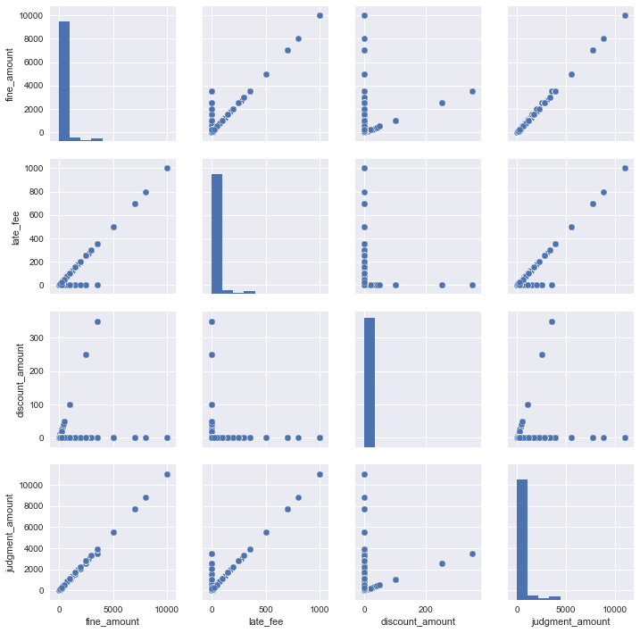

```python
cols =  ['fine_amount', 'late_fee', 'discount_amount', 'judgment_amount']
sns.pairplot(train[cols])
```

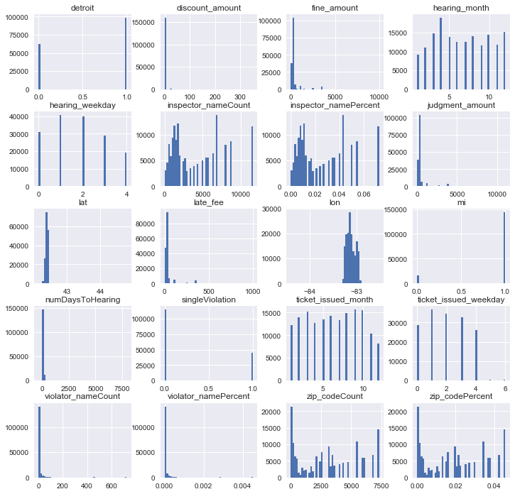

```python
train.hist(bins=50, figsize=(12, 12))
plt.show()
```

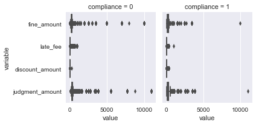

```python
trainNumerics = train[['fine_amount', 'late_fee', 'discount_amount', 'judgment_amount', 'compliance']]
g = sns.FacetGrid(pd.melt(trainNumerics, id_vars='compliance'), col='compliance')
g.map(sns.boxplot, 'value', 'variable')
```

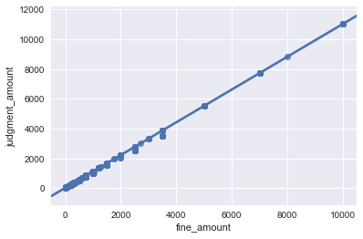

```python
sns.regplot(x='fine_amount', y='judgment_amount', data=train)
```

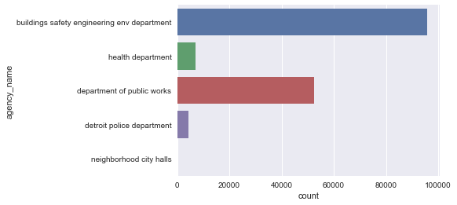

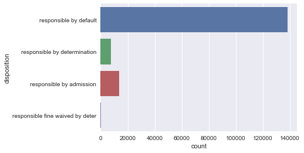

```python
for col in ['agency_name', 'disposition']:
    sns.countplot(y=col, data=train)  # vertical plot.  Change to y = col for horizontal plot
    plt.show()
```

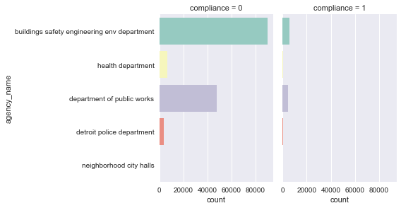

```python
sns.factorplot(y="agency_name", col="compliance", data=train, kind="count", palette="Set3")
```

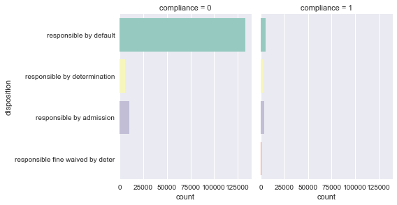

```python
sns.factorplot(y="disposition", col="compliance", data=train, kind="count", palette="Set3")
```

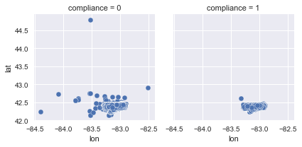

```python
g = sns.FacetGrid(train, col="compliance")
g = g.map(plt.scatter, "lon", "lat", edgecolor="w")
```

### More data clean-up based on exploration

#### Combine train and test set for more pre-processing

```python
train['set'] = 'train'
test['set'] = 'test'
df = pd.concat([train, test])
```

#### Check for highly correlated features

'fine_amount' and 'judgement_amount' looked highly correlated in the plot. Verify if they are indeed highly correlated and remove if necessary

```python
df['fine_amount'].corr(df['judgment_amount'])
```

```
0.98193710810739765
```

#### One-hot encoding for categorical features

```python
df =  pd.get_dummies(data = df, columns = ['agency_name', 'disposition', 'hearing_month', 'ticket_issued_month', 'hearing_weekday', 'ticket_issued_weekday',
                                           'inspector_name', 'violation_code'])
```

```python
print('New dataframe shape: ', df.shape)
```

```
New dataframe shape:  (220881, 519)
```

#### Remove sparse columns

Remove columns if there are fewer than 50 observations of '1' for the feature

```python
df = remove_features_fewer_than_count(df, 50)
print('New dataframe shape: ', df.shape)
```

```
New dataframe shape:  (220881, 276)
```

Remove columns if the standard deviation of the column is less than 0.001

```python
df = drop_features_based_on_std_threshold(df, 0.001)
print('New dataframe shape: ', df.shape)
```

```
New dataframe shape:  (220881, 275)
```

#### Save a backup of dataframe

```python
df.to_pickle('df.pkl')
```

#### Re-split data back to train and test

```python
train  = df.loc[df['set'] == 'train', :]
test  = df.loc[df['set'] == 'test', :]
```

#### Remove other unncessary columns

```python
cols = ['violation_street_number', 'violation_street_name',
           'mailing_address_str_number', 'mailing_address_str_name',
           'city', 'state', 'zip_code', 'country',
           'violationAddress', 'address',
           'inspector_name','violator_name','violation_description',
           'violation_code','agency_name','disposition', 'disposition_responsible compladj by default',
           'disposition_responsible compladj by determi', 'disposition_responsible fine waived by admis',
           'disposition_responsible fine waived by deter',
           'ticket_issued_date', 'hearing_date', 'violator_nameCount', 'zip_codeCount',
           'inspector_nameCount']
train = remove_columns(train, cols)
test = remove_columns(test, cols)
```

```python
trainY = train['compliance'].values
trainX = train.drop(['compliance','ticket_id', 'set'], axis = 1)
testX = test.drop(['compliance','ticket_id','set'], axis = 1)
```

#### Impute missing values using median

```python
imputer = Imputer(strategy="median")
imputer.fit(trainX)
trainX = imputer.transform(trainX)  # converts to float64 array
testX = imputer.transform(testX)
```

#### Normalize data

```python
normalizer = Normalizer(norm='l2', copy=True)
normalizer.fit(trainX)
trainX = normalizer.transform(trainX)  # converts to float64 array
testX = normalizer.transform(testX)
```

#### Split training set into train and validation set

```python
X_train, X_valid, y_train, y_valid = train_test_split(trainX, trainY, random_state = 0)
```

### Create Random Forest Model for prediction

#### Get baseline performance to beat

What the accuracy will be if the model always predict 'non-compliant' where compliance == 0

```python
train['compliance'].value_counts()/len(train)
```

```
0    0.927464
1    0.072536
Name: compliance, dtype: float64
```

#### Get baseline performance of a random forest model

```python
rf = RandomForestClassifier(random_state = 0)
rf.fit(X_train, y_train)
print("The accuracy of training set is: ", rf.score(X_train, y_train))
print("The accuracy of validation set is: ", rf.score(X_valid, y_valid))
```

```
The accuracy of training set is:  0.990451171712
The accuracy of validation set is:  0.941055791844
```

#### Variable importance of the baseline random forest model

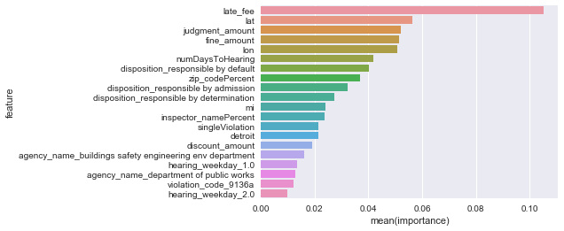

```python
varImp = rf.feature_importances_
varImpDf = pd.DataFrame(data= varImp, index=train.drop(['compliance','ticket_id', 'set'], axis = 1).columns)
varImpDf.reset_index(inplace=True)
varImpDf = varImpDf.sort_values([0], ascending = False).reset_index(drop = True)
varImpDf= varImpDf.rename(columns={'index':'feature', 0:"importance"})

sns.barplot(x="importance", y="feature", data=varImpDf.iloc[0:20,])
```

#### Closer look at a few features

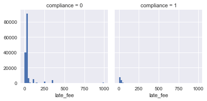

```python
g = sns.FacetGrid(train, col="compliance")
g = g.map(plt.hist, "late_fee", bins = 50)
```

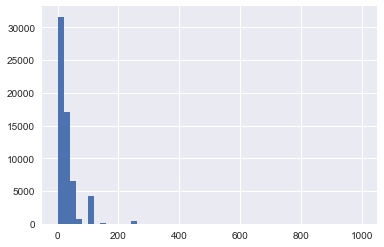

```python
test['late_fee'].hist(bins=50)
plt.show()
```

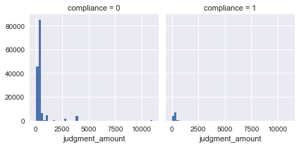

```python
g = sns.FacetGrid(train, col="compliance")
g = g.map(plt.hist, "judgment_amount", bins = 50)
```

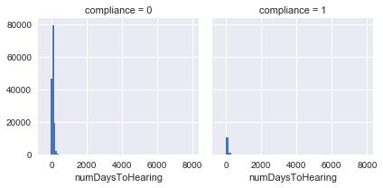

```python
g = sns.FacetGrid(train, col="compliance")
g = g.map(plt.hist, "numDaysToHearing", bins = 50)
```

#### Try a few randomized search parameters to see if performance of baseline model can be beaten

```python
param_distribs = {
        'n_estimators': [1000], # number of trees you want to build before taking the maximum voting
        'max_depth': [50, 75, 100], #
        'max_features': [0.5, 0.75] #maximum number of features Random Forest is allowed to try in individual tree
        }

rnd_search = RandomizedSearchCV(rf,
                                param_distributions=param_distribs,
                                n_iter=3,  #Number of parameter settings that are sampled
                                scoring='accuracy',
                                #cv = 5,
                                verbose=2,
                                n_jobs=3, #Number of jobs to run in parallel
                                random_state=0)


rnd_search.fit(X_train, y_train)
```

```
Fitting 3 folds for each of 3 candidates, totalling 9 fits
```

```
[Parallel(n_jobs=3)]: Done   9 out of   9 | elapsed: 439.7min remaining:    0.0s
[Parallel(n_jobs=3)]: Done   9 out of   9 | elapsed: 439.7min finished
```

```
RandomizedSearchCV(cv=None, error_score='raise',
          estimator=RandomForestClassifier(bootstrap=True, class_weight=None, criterion='gini',
            max_depth=None, max_features='auto', max_leaf_nodes=None,
            min_impurity_split=1e-07, min_samples_leaf=1,
            min_samples_split=2, min_weight_fraction_leaf=0.0,
            n_estimators=10, n_jobs=1, oob_score=False, random_state=0,
            verbose=0, warm_start=False),
          fit_params={}, iid=True, n_iter=3, n_jobs=3,
          param_distributions={'n_estimators': [1000], 'max_depth': [50, 75, 100], 'max_features': [0.5, 0.75]},
          pre_dispatch='2*n_jobs', random_state=0, refit=True,
          return_train_score=True, scoring='accuracy', verbose=2)
```

#### The best parameters from the randomized search:

```python
print("best parameters: ", rnd_search.best_params_ )
print("best estimator: ", rnd_search.best_estimator_)
```

```
best parameters:  {'n_estimators': 1000, 'max_features': 0.75, 'max_depth': 50}
best estimator:  RandomForestClassifier(bootstrap=True, class_weight=None, criterion='gini',
            max_depth=50, max_features=0.75, max_leaf_nodes=None,
            min_impurity_split=1e-07, min_samples_leaf=1,
            min_samples_split=2, min_weight_fraction_leaf=0.0,
            n_estimators=1000, n_jobs=1, oob_score=False, random_state=0,
            verbose=0, warm_start=False)
```

#### Save the cv results to a dataframe

```python
cvResult = pd.DataFrame(rnd_search.cv_results_)
print("validation score:" ,rnd_search.score(X_valid, y_valid))
```

```
validation score: 0.944683512634
```

```python
cvResult
```

|  | mean_fit_time | mean_score_time | mean_test_score | mean_train_score | param_max_depth | param_max_features | param_n_estimators | params | rank_test_score | split0_test_score | split0_train_score | split1_test_score | split1_train_score | split2_test_score | split2_train_score | std_fit_time | std_score_time | std_test_score | std_train_score |
| --- | --- | --- | --- | --- | --- | --- | --- | --- | --- | --- | --- | --- | --- | --- | --- | --- | --- | --- | --- |
| 0 | 10164.145866 | 16.984204 | 0.941323 | 0.999946 | 100 | 0.75 | 1000 | {'n_estimators': 1000, 'max_features': 0.75, '... | 3 | 0.941408 | 0.999950 | 0.940530 | 0.999950 | 0.942030 | 0.999937 | 245.142188 | 0.566821 | 0.000615 | 0.000006 |
| 1 | 6564.407771 | 16.550266 | 0.941940 | 0.999850 | 75 | 0.5 | 1000 | {'n_estimators': 1000, 'max_features': 0.5, 'm... | 2 | 0.942083 | 0.999950 | 0.941156 | 0.999950 | 0.942580 | 0.999650 | 134.224390 | 0.360168 | 0.000590 | 0.000142 |
| 2 | 9026.809114 | 13.283569 | 0.943858 | 0.986903 | 50 | 0.75 | 1000 | {'n_estimators': 1000, 'max_features': 0.75, '... | 1 | 0.944260 | 0.987128 | 0.943107 | 0.988229 | 0.944207 | 0.985352 | 44.997939 | 1.825938 | 0.000531 | 0.001185 |

Save best model as final model

```python
final_model = rnd_search.best_estimator_
joblib.dump(final_model, 'final_model.pkl')
```

```
['final_model.pkl']
```

```python
varImpRnd = final_model.feature_importances_
varImpDfRnd = pd.DataFrame(data= varImp, index=train.drop(['compliance','ticket_id', 'set'], axis = 1).columns)
varImpDfRnd.reset_index(inplace=True)
varImpDfRnd = varImpDfRnd.sort_values([0], ascending = False).reset_index(drop = True)
varImpDfRnd = varImpDfRnd.rename(columns={'index':'feature', 0:"importance"})
```

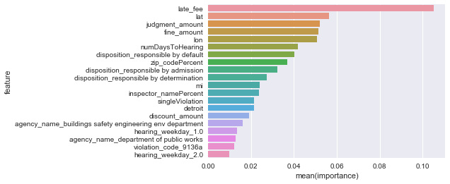

```python
sns.barplot(x="importance", y="feature", data=varImpDfRnd.iloc[0:20,])
```

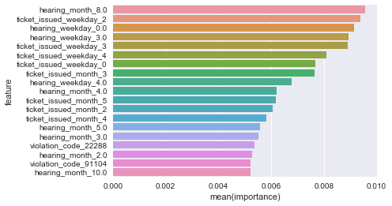

```python
sns.barplot(x="importance", y="feature", data=varImpDfRnd.iloc[21:40,])
```

What are the least important features?

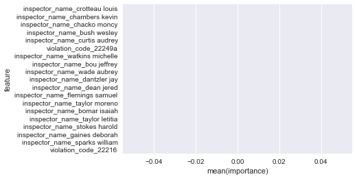

```python
sns.barplot(x="importance", y="feature", data=varImpDfRnd.iloc[-20:-1,])
```

#### Get prediction using the best estimator from the randomized search

```python
yPred =  final_model.predict(testX)
yProb = final_model.predict_proba(testX)[:,1]
submission = pd.Series(yProb, index = test['ticket_id'])
```

```python
submission.head()
```

```
ticket_id
284932    0.296790
285362    0.000989
285361    0.016064
285338    0.109827
285346    0.030135
dtype: float64
```